# Final Project

Ignat Kulinka

3/3/2022

### Introduction

As a response to the sudden COVID-19 pandemic, governments world-wide have resorted to a number of social policies designed to curtail the spread of the virus. In theory, these policies significantly reduce the number of infected individuals to a level that can be managed by healthcare systems. On the other hand, introduction of these containment policies has not been without a hefty price on global and local economies. The main goal of this project is to quantify the effect of government action on the spread of Coronavirus infections. Specifically, to measure potential impact of school and workplace closures on the number of daily new cases in order to better understand whether these policies are effective in halting the spread of the ongoing Coronavirus crisis and their potential in future pandemics. The main research question is to find whether these policies have a significant quantifiable effect on the number new cases of Coronavirus. In order to answer this question, three datasets are considered. World Health Organization ("WHO") Coronavirus Dashboard [1] dataset provides an ongoing daily number of new Coronavirus cases by country from early 2020. These are compared to the daily government policy indicator variables in the Oxford Covid-19 Government Response Tracker ("OxCGRT") [2] published by the Blavatnik School of Government at the University of Oxford. Particularly indicators for nation-wide school and workplace closures are used for the analysis. Lastly, the population data published by the World Bank [3] is utilized to better understand by-country trends in the previous datasets. In order to take into account the time series aspect of the WHO and OxCGRT a panel regression is utilized to regress the daily number of new cases on indicator variables of government policies in Portugal, France, Germany, The United Kingdom, and Italy.

### Background

On January 23, 2020, China imposed a first complete lockdown in the city of Wuhan [4]. Within several months’ time countless governments all over the world followed suit. By April, over 3.9 billion people in over 90 countries have been confined to their homes by their governments in an effort to “flatten” the epidemic curves [5]. As such, all but essential workers have been asked to work from home and students continued learning through remote instruction modes in order to ensure that the number of patients do not exceed hospital capacities. Since early 2020, most of the countries all over the world have went into and come out of lock down several times over. In the absence of a reliable vaccine against COVID-19, non pharmaceutical interventions (NPI) such as mask mandates and lockdowns have become a primary tool for government virus containment efforts. While lockdowns are likely to have had the intended effect of reducing the initial explosion of Coronavirus to proportions beyond hospital capacity, with time the effect on the most vulnerable people and economies has become extremely pronounced. For example, continuous isolation has also had a lasting impact as over 40% of U.S. adults have reported struggling with mental health or substance abuse [7]. Furthermore, World Bank estimates that as many as 50 million people have been pushed to extreme poverty as a result of lockdown policies [6]. As such, government decision makers worldwide have been presented with the dilemma on how to most effectively use lockdowns as a tool in the current crisis as well as potential future contagious virus outbreaks.

Besides this report, there has been an influx of effort in the academic community to provide policy makers with the most accurate data driven recommendations. Overall, literature review suggests two main approaches to quantifying the effect of social policies – first, using mathematical epidemiological model of infection spread, and the other using statistical approaches such as regression. While vastly different in practice both of these approaches rely on specific assumptions. In contrast to epidemiological models, the regression approach allows one to relax assumptions on individual human behavior through the use of real-world observations [8].

As such, this project falls squarely into the statistical regression bucket of analyses with the key aim to untangle the individual effect of school and workplace closures on the number of new cases. This is accomplished with the application of three datasets in a panel regression. Overall, the model is formulated by regressing the number of new COVID-19 cases on the lagged indicators of school and workplace closures. In this case lags from 1 to 21 days have been explored. In addition, the proposed panel regression model controls for country fixed effects to account for time-invariant effects and to manage omitted variable bias. In addition, some of the models explored include "time since the first case"" and "day of the week" dummy variables to absorb time-varying factors that might have an effect on the number of new cases. This is purely observational study and contains no sampling mechanism. As such the results are meant to be interpreted as associations between school and workplace closure and the number of new cases. While the data spans dozens of countries, in attempt to control for confounding variables such as weather patterns and to attempt at establishing reliable inferences of government containment policies on the number of new COVID-19 cases, countries with similar geographic locations, and experienced similar trends of Covid-19 were targeted. Additional criteria such as medical healthcare systems, socioeconomic level, and size were all considered in order to focus the analysis on Portugal, France, Germany, The United Kingdom, and Italy.

As mentioned above, three datasets were used in this analysis. The first piece of data comes from the World Health Organization. WHO is a highly credible international United Nations agency tasked with promoting health, expanding health coverage, and responding to emergencies [9]. In effort to spread awareness and transparency WHO publishes data related to Coronavirus in a dashboard updated daily. As such, the number of new Coronavirus cases is sourced directly from the dashboard. The data provided is structured in a daily format by country with additional fields documenting the number of cumulative cases as well as daily new deaths and cumulative deaths for 237 countries with data ranging from January 3, 2020 through February 17, 2022. The table below includes a summary of fields in the data -

| Column Name | Description |
| --- | --- |
| Date Reported | Date of reporting to WHO |
| Country Code | ISO Alpha-2 country code |
| Country | Country, territory, area |
| WHO Region | WHO regional office |
| New Cases | New confirmed cases. Calculated by subtracting previous cumulative case count from current cumulative cases count. |
| Cumulative Cases | Integer cumulative confirmed cases reported to WHO to date |
| New Deaths | New confirmed deaths. Calculated by subtracting previous cumulative deaths from current cumulative deaths. |
| Cumulative Deaths | Cumulative confirmed deaths reported to WHO to date |

Information on the government policies and their timing is sourced from Oxford Covid-19 Government Response Tracker ("OxCGRT") published by the Blavatnik School of Government at the University of Oxford. OxCGRT is an active crowd-sourced project that systematically collects information on policy measures taken by governments to tackle Coronavirus. It spans the time period from January 1, 2020 through February 18, 2022. Overall, the data set represents a daily by-country log of policies implemented and their respective strictness. As such it provides a unique opportunity for comparison and analysis. Among the 23 indicators provided only two are used for the purposes of this analysis. First, an indicator for school closure which tracks government mandates closures based on severity on a scale from zero to three. The second indicator is analogous but follows workplace closures instead. As part of the analysis WHO and OxCGRT are merged together by country and date to allow associations between policies and Coronavirus cases. A table describing the subset of fields utilized is included below.

| Column Name | Description |
| --- | --- |
| Country Name | Name of the country, region, area |
| Country Code | ISO Alpha-3 country code |
| Jurisdiction | National or region based record |
| Date | Date of the report |
| C1 School Closing | Closings of schools and universities |
| C2 Workplace Closing | Record closings of workplaces |

Note that each of the "C" fields is an ordinal with typical values of 0 through 3 which indicates the severity of the policy standardized across nations and contain the following levels -

- C1 School Closing
  - 0 - no measures
  - 1 - recommend closing or all schools open with alterations resulting in significant differences compared to non-Covid-19 operations
  - 2 - require closing (only some levels or categories, eg just high school, or just public schools)
  - 3 - require closing all levels
- C2 Workplace Closing
  - 0 - no measures
  - 1 - recommend closing (or recommend work from home) or all businesses open with alterations resulting in significant differences compared to non-Covid-19 operation
  - 2 - require closing (or work from home) for some sectors or categories of workers
  - 3 - require closing (or work from home) for all-but-essential workplaces (eg grocery stores, doctors)

Lastly, in an effort to further standardize by-country trends, population data published by the World Bank is utilized. In this case, a simple dataset with country population for over 250 regions in 2020. This data set contains four variables - Country name, Country Code, Indicator Code, and Population. Note that this data sets provides world and region population in addition to individual countries. Further discussion of the data is included in the Exploratory Data Analysis section.

| Column Name | Description |
| --- | --- |
| Country Name | Name of the country, region, area |
| Country Code | ISO Alpha-3 country code |
| Indicator Name | Indicator for the total population metric |
| Population | Total population for 2020 |

### Exploratory Data Analysis

#### Initial Review

Before the modeling stage of the analysis, the crucial step of data exploration is performed to compare and contrast data sets. As such, an initial review of each data source is performed. WHO data contains 777 data points for each of the 237 countries with a total of 184,149 records. Next, the WHO data set is analyzed for anomalies. First the data was checked for any abnormal or missing values. The summary table below captures summary statistics for each of the numeric variables.

|  | Min | 1st Quartile | Median | Mean | 3rd Quartile | Max |
| --- | --- | --- | --- | --- | --- | --- |
| New Cases | -32,952 | 0 | 21 | 2,262.37 | 487 | 1,327,952 |
| Cumulative Cases | 0 | 125 | 8,402 | 496,152.92 | 131,951 | 77,413,180 |
| New Deaths | -60 | 0 | 0 | 31.74 | 6 | 8,786 |
| Cumulative Deaths | 0 | 1 | 121 | 10,413.44 | 2,274 | 918,560 |

Clearly based on the summary statistics some additional data cleaning and aggregation is necessary due to negative New Cases and New Deaths values. These are most likely due to errors in reporting of cumulative statistics as those are used for calculation. As such there are 87 countries and over 5,000 records with either negative New Deaths or New Cases values. Further investigation of the data also indicated that nine countries such as Democratic People's Republic of Korea and Turkmenistan did not report any COVID cases or deaths to WHO. These countries are excluded from the analysis because due to the global scope and severity of Coronavirus, lack of cases and deaths is highly suspicious.

Next, the OxCGRT data is reviewed and analyzed for anomalies. As previously mentioned, the data set contains 186 countries with data ranging from January 1, 2020 through February 18, 2022. Summary statistics of the indicator variables are produced and included below.

|  | Min | 1st Quartile | Median | Mean | 3rd Quartile | Max |
| --- | --- | --- | --- | --- | --- | --- |
| C1 School Closing | 0 | 1 | 1 | 1.56 | 3 | 3 |
| C2 Workplace Closing | 0 | 1 | 1 | 1.36 | 2 | 3 |

The summary above provides a quick sanity check for any unexpected indicator variables outside of the definitions. As such it's evident that the range of each variable is within the defined values. The table also sheds some light on the policies implemented by world governments to contain and restrict Coronavirus over the January 1, 2020 through February 18, 2022 period. For example, a lower mean of workplace closings suggests that fewer countries implemented work from home mandates compared to school closures.

Next a similar review of the World Bank population data is conducted. As a result, the data contains a single data point for each of the 266 regions listed. Summary statistics for the population are recorded below. Note that the data sets also includes total world population as indicated by the max value of over seven billion.

|  | Min | 1st Quartile | Median | Mean | 3rd Quartile | Max |
| --- | --- | --- | --- | --- | --- | --- |
| Total Population in 2020 | 10,834 | 1,756,929 | 10,526,169 | 317,843,304 | 61,604,483 | 7,761,620,146 |

As the last step of the exploratory analysis data visualizations are created to review trends contained in the data. First the WHO data was used to understand the trends in new cases and new deaths over time. In order to smooth out the noise in the data, weekly average of new cases and new death for each of the WHO regions are plotted below using a line chart.

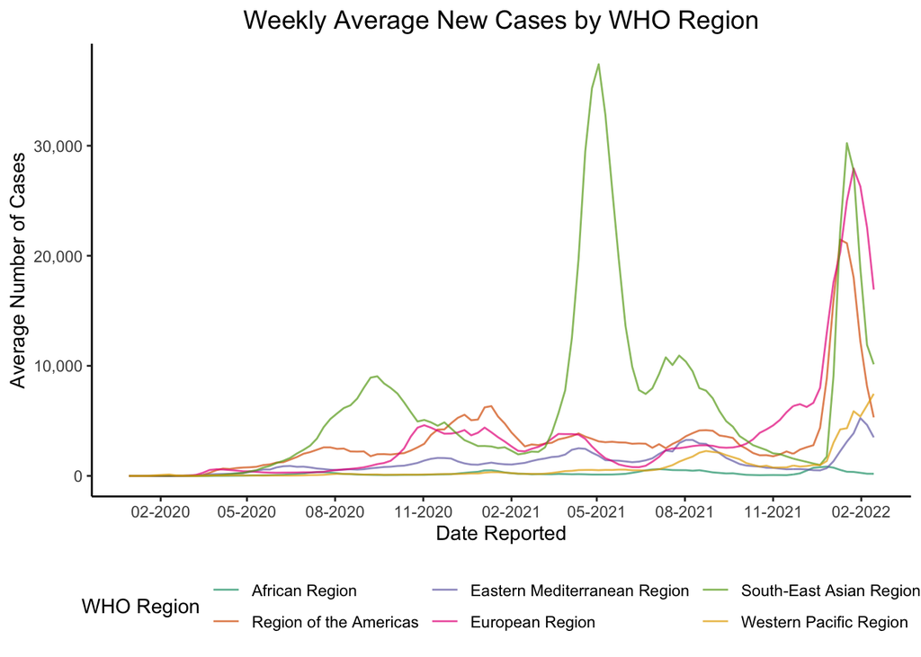

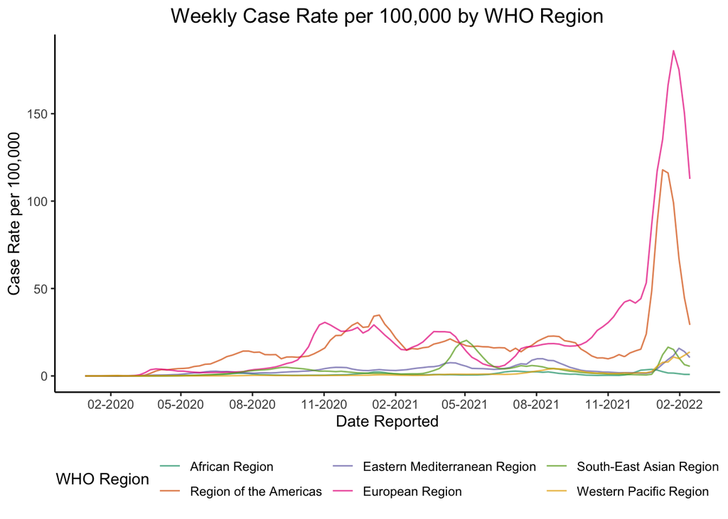

The above chart provides a much better summary of the trend in new cases by accounting for the population of each country/region. As such three different waves of new cases can be seen around November 2020, February 2021, and January 2022. When adjusting for population, South-East Asian Region is no longer the leader in cases and death. In fact, we can see that European and Americas Regions lead with a large number of cases in late 2020 and early 2022.

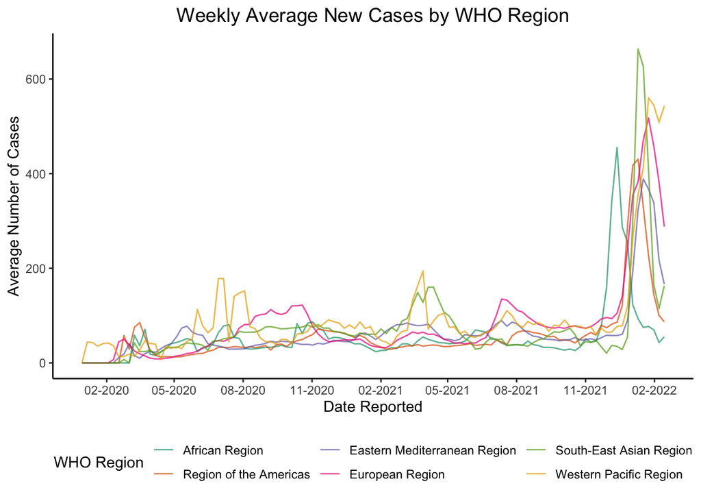

Lastly, the School Closing variable in OxCGRT is reviewed to understand the timeline of the initial government action in the face of the first wave of Coronavirus news in early 2020. For this analysis, the first government action regardless of the severity (levels 1 through 3) are recorded and plotted below. Note that the first chart compares all countries around the globe where the second one compares the data of the initial school closing between the African and European regions. For example, Italy had an initial school closing on February 23, 2020. This data point is counted in both plots for that date.

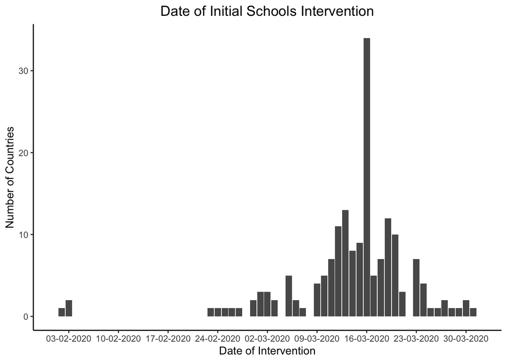

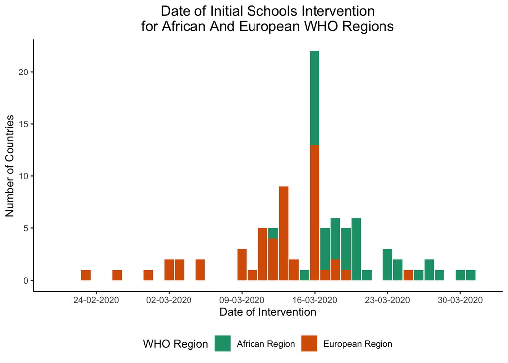

### Modeling

#### Methodology

The main research question of this report is to address and quantify the effect (or lack there) of government action on the spread of Coronavirus infections. That is, to measure potential impact of containment and closure policies such as school and workplace closure on the number of daily new cases. In other words - "Does government intervention through closing schools and workplaces affect the number of new Coronavirus cases?" In order to answer this question, a panel regression model is proposed to measure the impact of school and workplace closures on the average of new cases per 100,000.

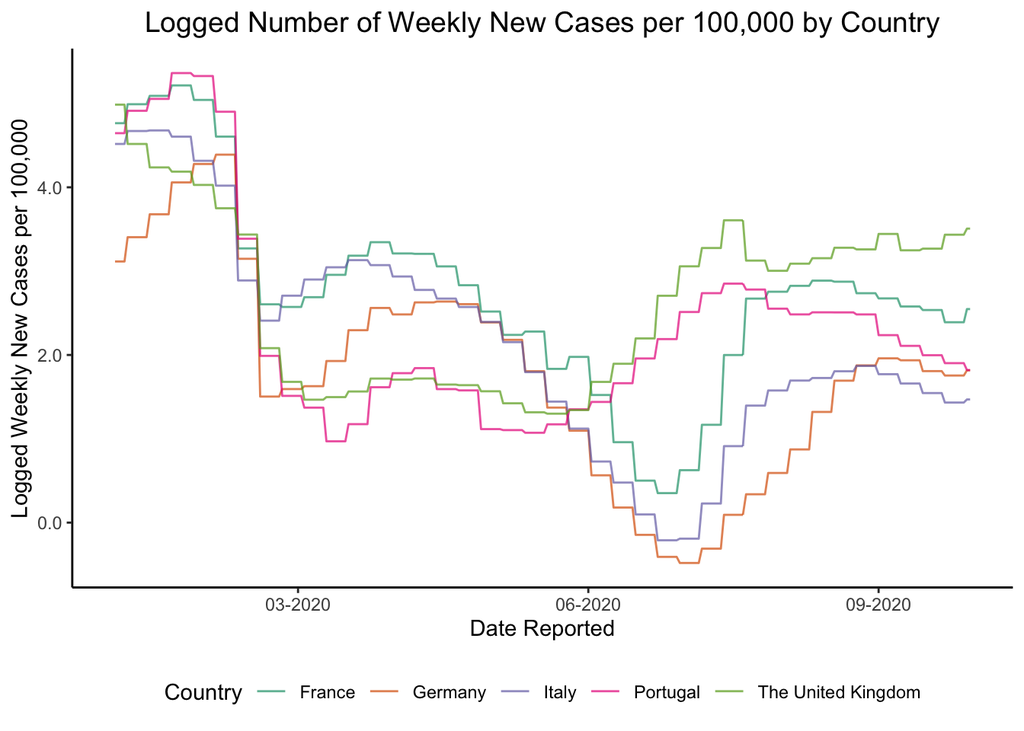

As demonstrated by the plot above, for each of the five countries the weekly number of new cases per 100,000 follows a similar trend. In addition, all of the five countries first implemented school and workplace closures around the same time in early 2020. Next, additional data preprocessing is applied to the C1 School Closing and C2 Workplace Closing variables. As mentioned above, these two variables are defined on an ordinal scale ranging from zero (no restrictions) to three (most severe). In order to better address the research question, these two variables are redefined into binary variables with zero (no restrictions) and one (any restrictions). This allows to test the hypothesis if any level of government intervention through school and workplace closing has an effect on number of new cases.

The panel regression model below is proposed to answer the research question. In this case, a panel regression model is relevant because of the structure of the data. That is for each day, each country has a row in the data which specifies number of new Coronavirus cases, number of new deaths as well as other information regarding the government containment policies. This data structure corresponds to panels over time. Panel regression is widespread and is a common econometric approach that contains more information and variability than time series data. In addition, this approach is preferred because it can minimize biases compared to cross-sectional data and time series approaches [10].

Below is a fixed effects panel regression model proposed in this project in order to measure the temporal effect of policy effects on the number of new cases. Note that the fixed effects model was chosen to understand the effect of government intervention within each country. This is an effective approach as it allows to control for time-invariant, slow to change economy-wide features that might have impact on the number of new cases such as demographic characteristics, public health systems, and weather patterns. The assumptions for this model are listed below and then checked in the Diagnostics section.

$$\text{log(Weekly Average New Cases per 100,000)}_{i,t}=\beta_0+\beta_1\text{School}_{i,t}+\beta_2\text{School}_{i,t-14}+\beta_3\text{Workplace}_{i,t} + \beta_4\text{Workplace}_{i,t-14}+\epsilon_{i,t}$$

where -

- $t=1,...,242$ days in the data for each country
- $i=1,...,5$ countries across all datasets
- $\text{log(Weekly Average New Cases per 100,000)}_{i,t}$: log of weekly average of new cases per 100,000 on day t in country i
- $\beta_0$: country specific, time invariant factor for country i
- $\text{School}_{i,t}$: dummy variable indicating restrictions on schools on day t in country i where 0 indicates no restrictions and 1 stands for any restrictions
- $\text{School}_{i,t-14}$: dummy variable indicating restrictions on schools on day t-14 in country i where 0 indicates no restrictions and 1 stands for any restrictions
- $\text{Workplace}_{i,t}$: dummy variable indicating restrictions on workplaces on day t in country i where 0 indicates no restrictions and 1 stands for any restrictions
- $\text{Workplace}_{i,t-14}$: dummy variable indicating restrictions on workplaces on day t-14 in country i where 0 indicates no restrictions and 1 stands for any restrictions
- $\epsilon_{i,t}$: idiosyncratic error term which contains the variation not captured by the other predictors in country i at time t

Note, literature review suggests that median COVID-19 incubation period has a median of 5 days and most develop symptoms within 12 days [11]. As such, the $\text{School}_{i,t-14}$ and $\text{Workplace}_{i,t-14}$ variables are included to account for long term effect of social policies. In the process of better understanding the data, a number of models was reviewed with lagged indicator variables in the range of 1 through 21 were compared and inspected for statistical significance. In this case, 14 was chosen as a balance between interpretability, prior literature review as well as statistical significance.

During the model fitting the following assumptions will need to be confirmed:

1. Covariates are exogenous: $E(\epsilon_i|x_{i1},..,x_{ki})=0$
2. Uncorrelated errors: $Cov(\epsilon_i,\epsilon_j)=0$.
3. Homoskedastic errors: $Var(\epsilon_i)=Var(y_i|x_{i1},..,x_{ki})=\sigma^2$.
4. Residuals are normally distributed.

#### Model Fitting

Below is a summary table of the fitted model. Note that the model summary table below indicates transformed estimated coefficients. These are transformed back and interpreted below.

|  | *Dependent variable:* |
| --- | --- |
|  | log(Weekly Average New Cases per 100,000) |
| School Closing t | -0.674*** |
|  | (0.159) |
| School Closing t-14 | 0.764*** |
|  | (0.172) |
| Workplace Closing t | -0.292* |
|  | (0.172) |
| Workplace Closing t-14 | -0.735*** |
|  | (0.146) |
| Observations | 1,210 |
| R<sup>2</sup> | 0.125 |
| Adjusted R<sup>2</sup> | 0.119 |
| F Statistic | 42.722*** (df = 4; 1201) |
| *Note:* | p<0.1; p<0.05; p<0.01 |

There are two major results to report from the table above. First, we reject the null hypothesis that the coefficients for school closure at t and t-14, as well as, workplace closure at t-14 are zero at $0.05%$ significance level. On the other hand, we fail to reject that the coefficient workplace closure at t is zero at the same level. In fact, this coefficient is only significant at $/alpha = 0.10$. In order to interpret these coefficients, it is first important to transform them. The table below compares the model output coefficients and transforms them.

| Coefficient | Original | Transformed |
| --- | --- | --- |
| School Closure t | -0.67 | -49.02 |
| School Closure t-14 | 0.76 | 114.65 |
| Workplace Closure t | -0.29 | -25.29 |
| Workplace Closure t-14 | -0.74 | -52.07 |

As we can see from the table above, it's clear that the final transformed versions of the coefficients for statistically significant predictors are negative with the exception of school closure at t-14. That is, we can see an instantaneous (from t to t-1) 49% decrease in average weekly new cases per 100,000 when school closure policies are instituted. This result suggests that there is a negative association between school closure policies and number of new COVID-19 cases. On the hand, we can not interpret the workplace closure coefficient in the same way because the coefficient is not significant at the same $/alpha=0.05$ level. That is the resulting instantaneous decrease of 25% in average weekly new cases per 100,000 could be due to chance. While the instantaneous effect for workplace closure is not significant, we can see that the lagged coefficient for workplace closure is significant and suggests a reduction of 50%. This result can be interpreted to mean that workplace closure policies are associated with a reduction in average number of new COVID-19 two weeks after the policy is instituted. Lastly, the coefficient for lagged school closures suggests a 114% increase in average COVID-19 cases two weeks after the policy is enacted. This is an unexpected result which suggests that the effect of school closure is reverse after two weeks. Furthermore, the strength of the increase suggests an overall increase after two weeks.

While the above model does not have the strongest $R^2$ value it provides a glimpse into the effect of closure policies for the five countries analyzed. Generally, the model does not attempt to control for all variation present in the model and further research is necessary into understanding potential confounding variables that might not be accounted for in the model. Note before we can form a solid conclusion it is necessary to review the model diagnostics and confirm that the model assumptions listed above are met.

### Diagnostics

Next, model assumptions are verified in order to draw conclusions from the above model. First a plot of the Residuals vs Fitted and Normal QQ are constructed in order to check whether the constant variance (homocedasticity) is achieved by the model and the errors are normally distributed.

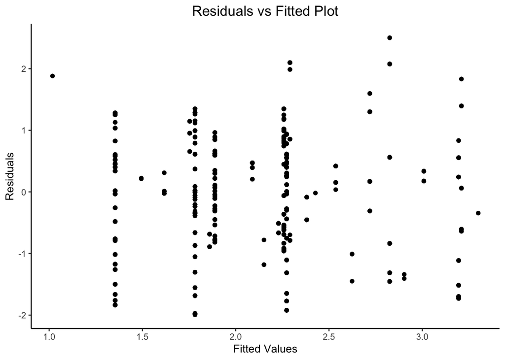

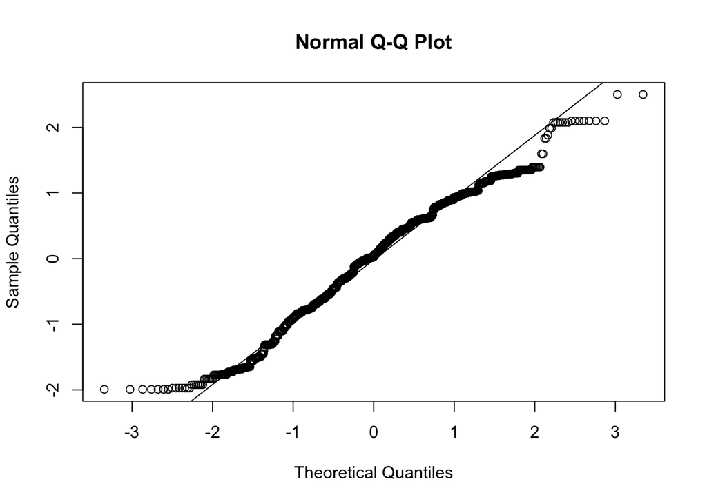

$$H_0: \text{Homoscedasticity is present}\quad \text{and} \quad H_1: \text{Heteroscedasticity is present}$$

We next check for serial correlation. In the panel regression context this can be accomplished using Bruesch-Godfrey/Wooldridge test. This test uses the following hypotheses:

$$H_0: \text{There is no autocorrelation}\quad \text{and} \quad H_1: \text{There exists autocorrelation}$$

Note that the output of this test yields a p-value of close to zero. Suggesting that we reject the null hypothesis at significance level of $\alpha=0.05$ and there is auto correlation present in the data. This suggests that the independence of residuals assumption is violated. In the future, this issue can be remedied by adding more lagged terms to the model or adding a seasonal dummy variable. In this model this is an issue that can lead to incorrect standard error calculation.

Lastly, we look into cross-sectional dependence. Which implies that there is an effect of some unobserved common factors that are affecting all of the units. That is not all of the predictors in the model are independent. This result can lead to potential issue with estimated coefficients. We use the follow Breusch-Pagan LM test to test for cross-sectional dependence in panels. The test procedure results in a p-value close to zero suggesting that we reject the null hypothesis at significance level of $\alpha=0.05$ and conclude that cross-sectional dependence is present in the model. Thus we conclude that the predictors are not independent violating one of the assumptions above.

$$H_0: \text{There is no cross-sectional dependence}\quad \text{and} \quad H_1: \text{There exists cross-sectional dependence}$$

Overall, we can see that there are some obvious issues with the model proposed. In fact, the tests above suggest that there auto correlation, non-constant error, and independence issues. At this stage, the model warrants a closer look to examine how to remedy these issues.

### Discussion

While the initial results of the model suggested that there is in fact a positive immediate effect of government containment policies on the number of new Coronavirus cases, the model diagnostics of the model prove the model inadequate for drawing any inferences or associations. In fact, once the model assumptions were scrutinized, clear departures became evident. In addition to rectifying issues with auto correlation, non-constant variance and independence it’s clear that further research into controlling for additional covariates is necessary.

Note that in this analysis, an observational study approach was adopted in order to draw associations between number of new Coronavirus cases and government containment policies. That is this project attempted to utilize the conditional ignorability assumption in order to draw meaningful inferences. As such a fixed effects panel regression model was coupled with a selection of countries of similar attributes in order to control for confounding variables. While the idea of controlling for countries and targeting only countries with similar demographics, healthcare systems and climates is a step in the right direction, finer controls over covariates is necessary. In fact, introducing more additional data into the model can help improve both the model fit and the diagnostic issues indicated above. It might be a good idea to include additional controls for age of the population, public transportation usage, climate, and socioeconomic level. For example, prior research suggests that both elderly and children are at the greatest risk for infection. As such, it might be fruitful to include demographic statistics (eg. percent of population over 70) directly into the model as blocking variables.

#### Citations

[1] WHO COVID-19 Dashboard. Geneva: World Health Organization, 2020. Available online: https://covid19.who.int/ (last cited: 2/18/2022).

[2] Thomas Hale, Noam Angrist, Rafael Goldszmidt, Beatriz Kira, Anna Petherick, Toby Phillips, Samuel Webster, Emily Cameron-Blake, Laura Hallas, Saptarshi Majumdar, and Helen Tatlow. (2021). “A global panel database of pandemic policies (Oxford COVID-19 Government Response Tracker).” Nature Human Behaviour. https://doi.org/10.1038/s41562-021-01079-8

[3] World Bank. "Population, total." World Development Indicators, The World Bank Group, 2019, https://data.worldbank.org/indicator/SP.POP.TOTL.

[4] Feng, Emily. “Wuhan's Lockdown Memories 1 Year Later: Pride, Anger, Deep Pain.” NPR, NPR, 23 Jan. 2021, https://www.npr.org/sections/goatsandsoda/2021/01/23/959618838/wuhans-lockdown-memories-one-year-later-pride-anger-deep-pain.

[5] Sandford, Alasdair. “Coronavirus: Half of Humanity on Lockdown in 90 Countries.” Euronews, 3 Apr. 2020, https://www.euronews.com/2020/04/02/coronavirus-in-europe-spain-s-death-toll-hits-10-000-after-record-950-new-deaths-in-24-hou.

[6] “The Impact of Covid-19 (Coronavirus) on Global Poverty: Why Sub-Saharan Africa Might Be the Region Hardest Hit.” World Bank Blogs, https://blogs.worldbank.org/opendata/impact-covid-19-coronavirus-global-poverty-why-sub-saharan-africa-might-be-region-hardest.

[7] “Mental Health, Substance Use, and Suicidal Ideation during the COVID-19 Pandemic - United States, June 24–30, 2020.” Centers for Disease Control and Prevention, Centers for Disease Control and Prevention, 29 Dec. 2020, https://www.cdc.gov/mmwr/volumes/69/wr/mm6932a1.htm.

[8] What Works to Control COVID-19? - Asian Development Bank. https://www.adb.org/sites/default/files/publication/659521/ewp-625-covid-19-econometric-analysis-cross-country-panel.pdf.

[9] “Frequently Asked Questions.” World Health Organization, World Health Organization, https://www.who.int/about/frequently-asked-questions.

[10] “Introduction to the Fundamentals of Panel Data.” Aptech, 3 Mar. 2021, https://www.aptech.com/blog/introduction-to-the-fundamentals-of-panel-data/.

[11] “Covid-19 Overview and Infection Prevention and Control Priorities in Non-U.S. Healthcare Settings.” Centers for Disease Control and Prevention, Centers for Disease Control and Prevention, https://www.cdc.gov/coronavirus/2019-ncov/hcp/non-us-settings/overview/index.html